# Executive Summary: An Exploration of the Success Variables of Hollywood Movies

Final Project  
Data Science 1 with R (STAT 301-1)

Author

Celena Kim

Published

December 8, 2023

**Github Repo Link**

https://github.com/stat301-1-2023-fall/final-project-1-celenakim

### Introduction

The purpose of this EDA report was to investigate the variables that contribute to the overall success rate of Hollywood movies. This was achieved by defining a movie’s success based on the factors of critic and audience ratings, opening weekend revenue, gross (domestic, foreign, and worldwide), budget and budget recovery, Oscar wins, and seasonal release date and exploring what possible patterns and correlations may exist among them to ultimately render a film to be a blockbuster or a flop.

### Data Quality Issues

Before highlighting some key findings from the report, it is important to note some significant issues in the data used for the EDA. The Kaggle data set “Hollywood Hits and Flops (2007 - 2023)” by David McCandless contains numerous unnecessary NA values, incorrect value conversions, and variables of types that were not conducive for a numerical analysis. Through an extensive cleaning process, most of these problems were able to be resolved. However, the issue of NA values still remains for the variables of primary genre, Oscar award detail, distributor company, and IMDb rating, making it difficult to perform accurate analyses with such variables.

### Key Finding 1: Economic Impact on Movie Success

In exploring the yearly changes in the variables of average opening weekend revenue, average domestic gross, and average productions budgets from 2007-2022, all three line plots displayed the same trend as the following figure:

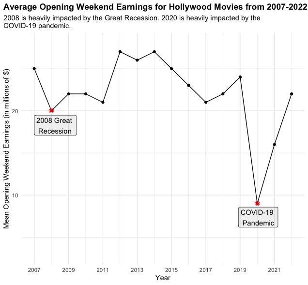

As can be seen in the graph, there are two distinct low points corresponding to the years 2008 and 2020. This recurring pattern of low averages for those years can be attributed to two economic turmoils that greatly impacted the film industry– the period of economic downturn in 2008 known as the Great Recession, and a nationwide quarantine in 2020 due to the COVID-19 pandemic. Specifically, for each variable:

- Opening weekend revenue: With the 2008 Great Recession, there was a dramatic decline in consumer spending and movie production, thus leading to a decline in the average earnings of movies in their first weekend of release. In 2020, the COVID-19 pandemic led to a nationwide shutdown/capacity limit of movie theaters, resulting in a drastic drop in films releases movie theater ticket sales and thus a dramatic drop in mean opening weekend revenues.
- Domestic Gross: Similar to above, the declines in consumer spending due to the 2008 Great Recession directly led to a drop in the total box office revenue of movies overall. In 2020, the movie theater shutdowns/limits due to quarantining for COVID-19 also directly led to declines in gross domestic revenue, as the movie theater industry was not very active during this period.
- Budget: Financial concerns induced by the 2008 Great Recession may have resulted in cost-cutting measures and a tightening of spending for movie distributors, thus leading to a lower average movie budget for that year. With the COVID-19 pandemic and quarantining, film studios may have delayed the production of their works, leading to an overall decline in film releases and therefore a decline in mean movie budgets for 2020.

These findings reveal how the film industry is significantly impacted by economic challenges, and how the success of movies is reflective of the overall economic success of the US.

### Key Finding 2: Seasonal Impact on Movie Release

Within my data set, I created a new variable to denote the season that each film was released in to explore whether distributors strategize their film releases by certain times of the year in order to increase their chances of being more successful or profitable. Numerous findings and patterns were revealed, but most notably, it seems that seasonal release has a profound impact on Oscar wins. According to the following graph, movies released in the Fall have won significantly more Oscar awards than movies released in other seasons.

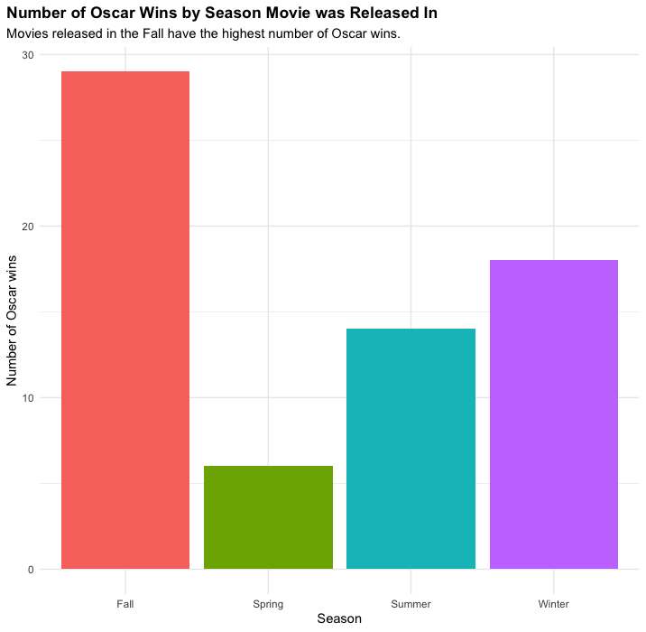

This could be the result of the Fall season being the optimal time of year for a film to be on the radar of Oscar voters– it is close enough in proximity to the period of Oscar voting and thus allows these films to be more relevant among the critics, yet it is also far enough away from the awards ceremony to allow the films to gain enough popularity and traction. From this, we can conclude that the time of the year does impact when distributors choose to release their movies, as releasing movies in the Fall seems to increase their chances of winning an Oscar.

### Key Finding 3: Correlation between movie rating and domestic gross revenue, by genre

Finally, the last key finding explores the relationship between a movie’s audience and critic ratings and it’s domestic gross revenue, compared across all possible movie genres.

[figure not shown]

### Conclusion

In all, these three key findings are just some of the many significant takeaways discovered in the report that ultimately answer the questions of what factors contribute to a movie’s overall success rate, what relationships exist between such variables, and what the ideal conditions of such variables are in order to render a movie to be a hit. Movie success is a multifaceted concept that can be defined by various creative means from high opening weekend revenue to Oscar wins, and is influenced by a variety of factors such as economic atmospheres and time of the year. Exploring a wide range of such variables and other determinants that may impact a movie’s performance ultimately serves to provide a comprehensive understanding of the film industry and its span of famed blockbusters and unnoticed flops.